# Ahmed-Atef: Traffic Data Analysis

```r
library(ggplot2)
library(dplyr)
traffic.data <- read.csv("../traffic-data.csv", header=FALSE,encoding="UTF-8")
```

Reading the data and loading the libraries needed

# Data cleaning

Checking the dimininsions of the given data

```r
traffic.data %>% dim
```

```
## [1] 429983     34
```

Trying to understand what each column indicates by checking the full content of the first few rows.

```r
traffic.data %>% head
```

```
##                             V1     V2      V3       V4      V5       V6
## 1                   crawl_date ad/aid ad/bgcl ad/bgcls ad/fncl ad/fncls
## 2 Fri Feb  5 17:23:57 UTC 2016   2538 #003768  #0069aa #FFFFFF  #FFFFFF
## 3 Fri Feb  5 17:23:57 UTC 2016   2538 #003768  #0069aa #FFFFFF  #FFFFFF
## 4 Fri Feb  5 17:23:57 UTC 2016   2538 #003768  #0069aa #FFFFFF  #FFFFFF
## 5 Fri Feb  5 17:23:57 UTC 2016   2538 #003768  #0069aa #FFFFFF  #FFFFFF
## 6 Sat Feb  6 08:01:00 UTC 2016   2538 #003768  #0069aa #FFFFFF  #FFFFFF
##       V7                                                       V8
## 1 ad/lid                                                  ad/logo
## 2   1001 http://www.bey2ollak.com/downloads/logos/Pepsi_SA7EL.png
## 3   1001 http://www.bey2ollak.com/downloads/logos/Pepsi_SA7EL.png
## 4   1001 http://www.bey2ollak.com/downloads/logos/Pepsi_SA7EL.png
## 5   1001 http://www.bey2ollak.com/downloads/logos/Pepsi_SA7EL.png
## 6   1001 http://www.bey2ollak.com/downloads/logos/Pepsi_SA7EL.png
##                                                            V9
```

[output cut: 62 more lines]

it was clear that the column names were presented in the first row so the column names are renamed with the values in the first row

```r
names(traffic.data) <-  traffic.data[1,] %>% unlist
traffic.data <- traffic.data[-1,]
```

The data columns is divided into two category groups ad and then there is a rd category , the columns of ad will be selected and observed trying to understand them serparetly by looking at some entries

```r
 traffic.data %>% select(starts_with("ad")) %>% glimpse
```

```
## Observations: 429,982
## Variables: 13
## $ ad/aid          (fctr) 2538, 2538, 2538, 2538, 2538, 2538, 2538, 253...
## $ ad/bgcl         (fctr) #003768, #003768, #003768, #003768, #003768, ...
## $ ad/bgcls        (fctr) #0069aa, #0069aa, #0069aa, #0069aa, #0069aa, ...
## $ ad/fncl         (fctr) #FFFFFF, #FFFFFF, #FFFFFF, #FFFFFF, #FFFFFF, ...
## $ ad/fncls        (fctr) #FFFFFF, #FFFFFF, #FFFFFF, #FFFFFF, #FFFFFF, ...
## $ ad/lid          (fctr) 1001, 1001, 1001, 1001, 1001, 1001, 1001, 100...
## $ ad/logo         (fctr) http://www.bey2ollak.com/downloads/logos/Peps...
## $ ad/logo2x       (fctr) http://www.bey2ollak.com/downloads/logos/Peps...
## $ ad/logoAndroidS (fctr) http://www.bey2ollak.com/downloads/logos/Peps...
## $ ad/logoAndroidH (fctr) http://www.bey2ollak.com/downloads/logos/Peps...
## $ ad/cm           (fctr) دوس هنا وشوف إعلان بيبسي الجديد مع محمد صلاح ...
## $ ad/url          (fctr) http://youtu.be/aNeqShdgupY, http://youtu.be/...
## $ ad/g            (fctr) 1, 1, 1, 1, 1, 1, 1, 1, 1, 1, 1, 1, 1, 1, 1, ...
```

Checking the number of unique values inside each column of the ads

```r
traffic.data %>% select(starts_with("ad")) %>% rapply(function(x) length(unique(x)))
```

```
##          ad/aid         ad/bgcl        ad/bgcls         ad/fncl
##               1               1               1               1
##        ad/fncls          ad/lid         ad/logo       ad/logo2x
##               1               1               1               1
## ad/logoAndroidS ad/logoAndroidH           ad/cm          ad/url
##               1               1               1               1
##            ad/g
##               1
```

All of the advertisment columns has only one unique value so they are meaningless and should be omitted from the data

```r
traffic.data <- traffic.data %>% select(-starts_with("ad")) %>% subset
```

Now checking the rd columns and trying to understand what each column represents first the same function to check unique values is applied to remove unnecessary columns without the need to know their meaning

```r
 traffic.data %>% select(starts_with("rd")) %>% rapply(function(x) length(unique(x)))
```

```
##        rd/nm        rd/ri      rd/stid        rd/hr        rd/mn
##          301          305           11           71           61
##       rd/new       rd/img        rd/cl      rd/strq      rd/cmrq
##            2            2            1            2            2
##     rd/rp/nm rd/rp/fullnm     rd/rp/hr     rd/rp/mn   rd/rp/stid
##        16759        14115           93           60           11
##     rd/rp/cm   rd/rp/cmid  rd/rp/rpImg    rd/rp/img   rd/rp/type
##        44716       148367         6277         6660            1
```

removing the rd/cl and rd/rp/type columns as they contain just one value so they are meaningless aswell

```r
 col <-  c("rd/cl", "rd/rp/type")
 traffic.data <- traffic.data %>% select(- one_of(col)) %>% subset
```

Checking the content of the columns that has 2 unique values to check if they are neccessary to have

```r
 col <- c("rd/img","rd/strq","rd/cmrq","rd/new")
traffic.data %>% select(one_of(col)) %>% rapply(function(x) unique(x))
```

```
##  rd/img1  rd/img2 rd/strq1 rd/strq2 rd/cmrq1 rd/cmrq2  rd/new1  rd/new2
##     <NA>        T        1        0        0        1        1        0
## Levels: rd/img T 0 1 rd/strq rd/cmrq rd/new
```

Noticing the values these are probably true/false values that maybe relevant so only the rd/img1 column is removed

```r
 col <-  c("rd/img")
 traffic.data <- traffic.data %>% select(- one_of(col)) %>% subset
```

Checking the number of NA values in each column and compare it to the number of unique values

```r
 traffic.data %>%  rapply(function(x) length(unique(x)))
```

```
##   crawl_date        rd/nm        rd/ri      rd/stid        rd/hr
##        28331          301          305           11           71
##        rd/mn       rd/new      rd/strq      rd/cmrq     rd/rp/nm
##           61            2            2            2        16759
## rd/rp/fullnm     rd/rp/hr     rd/rp/mn   rd/rp/stid     rd/rp/cm
##        14115           93           60           11        44716
##   rd/rp/cmid  rd/rp/rpImg    rd/rp/img
##       148367         6277         6660
```

```r
 traffic.data %>%  rapply(function(x) length(which(is.na(x))))
```

```
##   crawl_date        rd/nm        rd/ri      rd/stid        rd/hr
##            0            0            0        30100         1507
##        rd/mn       rd/new      rd/strq      rd/cmrq     rd/rp/nm
##         1507            0            0            0            0
## rd/rp/fullnm     rd/rp/hr     rd/rp/mn   rd/rp/stid     rd/rp/cm
##        52055            0            0        13965            0
##   rd/rp/cmid  rd/rp/rpImg    rd/rp/img
##            0       411585       152557
```

It is clear that the columns “rd/rp/rpImg” and “rd/rp/img” are not relevant to our data due to the extremly high number of NAs that are found and the low number of unique value , also an img would be irrelevant to our study so they are removed

```r
 col <- c("rd/rp/rpImg","rd/rp/img")
 traffic.data <- traffic.data %>% select(- one_of(col)) %>% subset
```

Looking at the remaining columns and exploring random rows some of the variables are clear what they represent

- **crawl_date** is the time the data was crawled
- **rd/name** is the name of the road sometimes contains the name of start and destination aswell
- **rd/hr And rd/mn** since this is a time associated with the road it is probably the time this road was last updated
- **rd/new** is a boolean indicating whether the road is new or not
- **rd/rp/nm And rd/rp/fullnm** is the name of the person reporting
- **rp/rp/hr And rd/rp/mn** since this is a time associated with the person it is probably the time of report or the time passed since this person reported not sure yet
- **rd/rp/cm** is the comment of the person it is either a written comment or one of the categories built in the app
- **rd/rp/cmid** is probably the id of the comment

The columns **rd/streq** , **rd/cmrq** , **rd/ri** , **rd/stid** and **rd/rp/stid** are still not clear and need further investigations

It is not that easy to remove the duplicates in the entries as similar reports of the same person would have different attributes such as crawl_date or the times.

If __rd/rp/cmid_ is really the comment id of the person then this should be unique and can be used to remove duplicate rows so we check this by sorting based on the cmid

```r
traffic.data %>% arrange(`rd/rp/cmid`) %>% head
```

```
##                     crawl_date                                     rd/nm
## 1 Sun Feb  7 14:00:42 UTC 2016                         توتال (برج العرب)
## 2 Sun Feb  7 14:30:44 UTC 2016                         توتال (برج العرب)
## 3 Sun Feb  7 15:00:42 UTC 2016                         توتال (برج العرب)
## 4 Sat Feb  6 08:30:23 UTC 2016 El Dawly;Borg El 3arab To Maw2af El Gedid
## 5 Sat Feb  6 09:00:23 UTC 2016 El Dawly;Borg El 3arab To Maw2af El Gedid
## 6 Sat Feb  6 09:30:23 UTC 2016 El Dawly;Borg El 3arab To Maw2af El Gedid
##   rd/ri rd/stid rd/hr rd/mn rd/new rd/strq rd/cmrq          rd/rp/nm
## 1   485    <NA>   139    14      0       0       1         AkramSeef
## 2   485    <NA>   139    44      0       0       1         AkramSeef
## 3   485    <NA>   140    14      0       0       1         AkramSeef
## 4   242    <NA>    41    51      0       1       0 theblackdevil2020
## 5   242    <NA>    42    21      0       1       0 theblackdevil2020
## 6   242    <NA>    42    51      0       1       0 theblackdevil2020
##   rd/rp/fullnm rd/rp/hr rd/rp/mn rd/rp/stid  rd/rp/cm rd/rp/cmid
## 1         <NA>      139       14          2     aaaaa    9271509
## 2         <NA>      139       44          2     aaaaa    9271509
## 3         <NA>      140       14          2     aaaaa    9271509
## 4        johnn       65       32          5 وااااااقف    9287496
## 5        johnn       66        2          5 وااااااقف    9287496
## 6        johnn       66       32          5 وااااااقف    9287496
```

Noticing the entries having the same cmid represents the same comment the differences are in the crawl_date as the data is crawled every 30 minutes , rd/mn rd/hr which represents the last time road was updated , and rd/rp/hr rd/rp/mn which increases by 30 minutes aswell thus confirming that this time represents the time passed since this person made the report Now it is safe to remove duplicate rows based on rd/rp/cmid values

```r
traffic.data <- traffic.data %>% subset(!duplicated(`rd/rp/cmid`))
```

Since the time that has passed since the report was made is really a useless information in its current state it should be changed to reflect the actual time the report was made . So the crawl_date column values are changed to Date-time format

```r
 traffic.data$crawl_date <- strptime(traffic.data$crawl_date,  "%a %b %d %H:%M:%S",tz = "UTC")
```

Now a new column is introduced containing the actual time of the report which is done by subtracting the report time from the crawl_date

```r
traffic.data$`rd/rp/hr` <- as.numeric(traffic.data$`rd/rp/hr`)
traffic.data$`rd/rp/mn` <- as.numeric(traffic.data$`rd/rp/mn`)
traffic.data$Report_Time <- (traffic.data$crawl_date - (traffic.data$`rd/rp/hr` * 3600 + traffic.data$`rd/rp/mn` * 60))
```

Now the previous report times are meaningless and are droppped

```r
traffic.data$`rd/rp/hr` <- NULL
traffic.data$`rd/rp/mn` <- NULL
```

```r
  temp <- traffic.data[2:15] %>% group_by(`rd/nm`) %>% summarize(distinct = n_distinct(`rd/ri`))
 temp <-  temp %>% subset(temp$distinct != 1)
```

So there exist roads having 2 ids one is “Other Roads” and the other is “Sa7rawy;Cairo To Alex” and looking to a sample of each

```r
 temp <- traffic.data %>% subset(`rd/nm` == "Sa7rawy;Cairo To Alex" )
 temp <- temp[!duplicated(temp$`rd/ri`),]

  temp <- traffic.data %>% subset(`rd/nm` == "Other Roads" )
 temp <- temp[!duplicated(temp$`rd/ri`),]
```

we find that road it of sa7rawy can take either “307” or “523” and Other roads can take “21” or “99” and this confirms that rd/ri corresponds to road ID

Now there is an issue in the rd/nm column as it contains not just the road name but sometimes the start and destination of the person in the format road_name;Start to Destination so the column should be parsed and new columns having start and destination should be added

```r
 traffic.data$Road_Name <- lapply(strsplit(as.character(traffic.data$`rd/nm`), ";"), "[", 1)
 traffic.data$StartEnd <- lapply(strsplit(as.character(traffic.data$`rd/nm`), ";"), "[", 2)
 traffic.data$Start <-lapply(strsplit(as.character(traffic.data$StartEnd), "To"), "[", 1)
 traffic.data$Destination <-lapply(strsplit(as.character(traffic.data$StartEnd), "To"), "[", 2)
 traffic.data$StartEnd <- NULL
```

**rd/streq** , **rd/cmrq** , **rd/stid** and **rd/rp/stid** are still unclear so we try to figure out what they represent

Since people can report the state of traffic into one of the following categories: 7alawa,lazeez,mashy,za7ma,mafeesh 2amal or write their own comment , we can filter all the rows with a category and try to find a pattern in a variable unknown

Doing this for all categories

```r
traffic.data[,c("rd/rp/cm","rd/rp/stid","rd/stid", "rd/strq" , "rd/cmrq")] %>% subset(`rd/rp/cm` == "7alawa" ) %>% rapply(function(x) length(unique(x)))
```

```
##   rd/rp/cm rd/rp/stid    rd/stid    rd/strq    rd/cmrq
##          1          2          8          1          2
```

```r
 traffic.data[,c("rd/rp/cm","rd/rp/stid","rd/stid", "rd/strq" , "rd/cmrq")] %>% subset(`rd/rp/cm` == "7alawa" ) %>% rapply(function(x) (unique(x)))
```

```
##    rd/rp/cm rd/rp/stid1 rd/rp/stid2    rd/stid1    rd/stid2    rd/stid3
##      7alawa           1           2        <NA>           2           6
##    rd/stid4    rd/stid5    rd/stid6    rd/stid7    rd/stid8     rd/strq
##           3          10           4           1           5           1
##    rd/cmrq1    rd/cmrq2
##           0           1
## 44731 Levels: ;( :-( :/ :'( :( :(( :(((((((((((((((((((( :) :@ ! !! ... rd/cmrq
```

Now we try the second cateogry “lazeez”

```r
traffic.data[,c("rd/rp/cm","rd/rp/stid","rd/stid", "rd/strq" , "rd/cmrq")] %>% subset(`rd/rp/cm` == "lazeez" ) %>% rapply(function(x) length(unique(x)))
```

```
##   rd/rp/cm rd/rp/stid    rd/stid    rd/strq    rd/cmrq
##          1          3          9          2          2
```

```r
 traffic.data[,c("rd/rp/cm","rd/rp/stid","rd/stid", "rd/strq" , "rd/cmrq")] %>% subset(`rd/rp/cm` == "lazeez" ) %>% rapply(function(x) (unique(x)))
```

```
##    rd/rp/cm rd/rp/stid1 rd/rp/stid2 rd/rp/stid3    rd/stid1    rd/stid2
##      lazeez           2           1           3           3        <NA>
##    rd/stid3    rd/stid4    rd/stid5    rd/stid6    rd/stid7    rd/stid8
##           2           4           6           5           1          10
##    rd/stid9    rd/strq1    rd/strq2    rd/cmrq1    rd/cmrq2
##           9           1           0           0           1
## 44731 Levels: ;( :-( :/ :'( :( :(( :(((((((((((((((((((( :) :@ ! !! ... rd/cmrq
```

rd/rp/stid gets 3 values which are either 1 or 2 or 3 and rd/strq takes 1 except for one entry and rd/cmrq takes 0 except for 2 entries

```r
traffic.data[,c("rd/rp/cm","rd/rp/stid","rd/stid", "rd/strq" , "rd/cmrq")] %>% subset(`rd/rp/cm` == "mashy" ) %>% rapply(function(x) length(unique(x)))
```

```
##   rd/rp/cm rd/rp/stid    rd/stid    rd/strq    rd/cmrq
##          1          3          9          1          1
```

```r
 traffic.data[,c("rd/rp/cm","rd/rp/stid","rd/stid", "rd/strq" , "rd/cmrq")] %>% subset(`rd/rp/cm` == "mashy" ) %>% rapply(function(x) (unique(x)))
```

```
##    rd/rp/cm rd/rp/stid1 rd/rp/stid2 rd/rp/stid3    rd/stid1    rd/stid2
##       mashy           3           2           4           2           3
##    rd/stid3    rd/stid4    rd/stid5    rd/stid6    rd/stid7    rd/stid8
##        <NA>           4           6           1          10           5
##    rd/stid9     rd/strq     rd/cmrq
##           9           1           0
## 44731 Levels: ;( :-( :/ :'( :( :(( :(((((((((((((((((((( :) :@ ! !! ... rd/cmrq
```

Then we try “za7ma”

```r
traffic.data[,c("rd/rp/cm","rd/rp/stid","rd/stid", "rd/strq" , "rd/cmrq")] %>% subset(`rd/rp/cm` == "za7ma" ) %>% rapply(function(x) length(unique(x)))
```

```
##   rd/rp/cm rd/rp/stid    rd/stid    rd/strq    rd/cmrq
##          1          4         10          2          2
```

```r
 traffic.data[,c("rd/rp/cm","rd/rp/stid","rd/stid", "rd/strq" , "rd/cmrq")] %>% subset(`rd/rp/cm` == "za7ma" ) %>% rapply(function(x) (unique(x)))
```

```
##    rd/rp/cm rd/rp/stid1 rd/rp/stid2 rd/rp/stid3 rd/rp/stid4    rd/stid1
##       za7ma           4           3           5        <NA>           3
##    rd/stid2    rd/stid3    rd/stid4    rd/stid5    rd/stid6    rd/stid7
##           2           6           5           4           1        <NA>
##    rd/stid8    rd/stid9   rd/stid10    rd/strq1    rd/strq2    rd/cmrq1
##          10           8           9           1           0           0
##    rd/cmrq2
##           1
## 44731 Levels: ;( :-( :/ :'( :( :(( :(((((((((((((((((((( :) :@ ! !! ... rd/cmrq
```

Then the last category “mafeesh 2amal”

```r
traffic.data[,c("rd/rp/cm","rd/rp/stid","rd/stid", "rd/strq" , "rd/cmrq")] %>% subset(`rd/rp/cm` == "mafeesh 2amal" ) %>% rapply(function(x) length(unique(x)))
```

```
##   rd/rp/cm rd/rp/stid    rd/stid    rd/strq    rd/cmrq
##          1          1          1          1          1
```

```r
 traffic.data[,c("rd/rp/cm","rd/rp/stid","rd/stid", "rd/strq" , "rd/cmrq")] %>% subset(`rd/rp/cm` == "mafeesh 2amal" ) %>% rapply(function(x) (unique(x)))
```

```
##      rd/rp/cm    rd/rp/stid       rd/stid       rd/strq       rd/cmrq
## mafeesh 2amal             5             4             1             0
## 44731 Levels: ;( :-( :/ :'( :( :(( :(((((((((((((((((((( :) :@ ! !! ... rd/cmrq
```

For the last category “mafeesh 2amal” the rd/rp/stid can take up only one value 5 and rd/strq takes only one value 1 and rd/cmrq takes 1 values which is 0

So this is checked by checking how many values in the data contains rd/strq = 1 and how many contains rd/cmrq = 0

```r
nrow(traffic.data %>% subset(`rd/strq` == "1"))
```

```
## [1] 141433
```

```r
nrow(traffic.data %>% subset(`rd/cmrq` == "0"))
```

```
## [1] 138290
```

So out of the 148367 rows there is 141433 with rd/strq = 1 and 138290 with rd/cmrq = 0 so probably this information is not meaningfull or even if it is it will not contribute much to the analysis of the data .

Changing the column names of the data

```r
 colnames(traffic.data)[which(colnames(traffic.data) == 'rd/rp/stid')] <- 'Report_Status'
 colnames(traffic.data)[which(colnames(traffic.data) == 'rd/ri')] <- 'Road_ID'
 colnames(traffic.data)[which(colnames(traffic.data) == 'rd/new')] <- 'Road_IsNew'
 colnames(traffic.data)[which(colnames(traffic.data) == 'rd/rp/nm')] <- 'Reporter_Name'
 colnames(traffic.data)[which(colnames(traffic.data) == 'rd/rp/fullnm')] <- 'Reporter_Full_Name'
 colnames(traffic.data)[which(colnames(traffic.data) == 'rd/rp/cm')] <- 'Reporter_Comment'
 colnames(traffic.data)[which(colnames(traffic.data) == 'rd/rp/cmid')] <- 'Reporter_Comment_ID'
```

From knowing the Report_Status its safe to ignore the comment of the reporter and just use it as indication of the road status .

Now the we can know information from the data such as trying to figure out the raods with the worst traffic and the roads that hes least traffic

Roads with least traffic

```r
 traffic.data[2:17] %>% group_by(as.character(Road_Name)) %>% summarize(traffic = mean(as.numeric(Report_Status))) %>% arrange(traffic)
```

```
## Source: local data frame [124 x 2]
##
##       as.character(Road_Name)  traffic
##                         (chr)    (dbl)
## 1           Mohamed Nageeb St 1.888889
## 2                     NA Road 2.100735
## 3                     ElDawly 2.145833
## 4     Waslet Pyramids Heights 2.216216
## 5                  Nozha Road 2.250000
## 6                   Port Said 2.572289
## 7      Khaled Ebn ElWaleed St 2.598214
## 8  Masged ElKa2ed Ibrahim St. 2.605505
## 9                Kobry 3abbas 2.609639
## 10              Kobry ElGam3a 2.625148
## ..                        ...      ...
```

Roads with worst traffic

```r
traffic.data[2:17] %>% group_by(as.character(Road_Name)) %>% summarize(traffic = mean(as.numeric(Report_Status))) %>% arrange(desc(traffic))
```

```
## Source: local data frame [124 x 2]
##
##          as.character(Road_Name)  traffic
##                            (chr)    (dbl)
## 1                  Lotfy ElSayed 5.666667
## 2       Ta7t K.October(Mahmasha) 4.893504
## 3  Ta7t K.October(Lotfy ElSayed) 4.877211
## 4                 Midan ElTa7rir 4.514589
## 5                     Mansoureya 4.379518
## 6                    Zera3y Road 4.311192
## 7            Me7war Saft ElLaban 4.274986
## 8                    Faissal St. 4.234756
## 9                   West ElBalad 4.056162
## 10                       Zamalek 4.021635
## ..                           ...      ...
```

And here is the graph

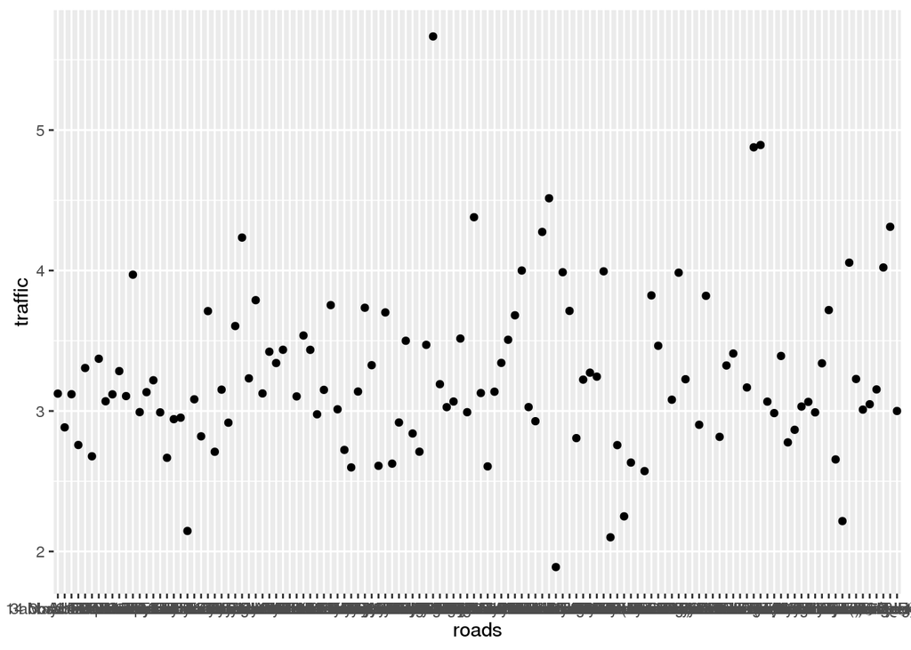

```r
 a<- traffic.data[2:17] %>% group_by(roads = as.character(Road_Name)) %>% summarize(traffic = mean(as.numeric(Report_Status)))
 p <- ggplot(a, aes(roads, traffic))
 p + geom_point()
```

Deadline !